# Projekt2.0

Bartłomiej Kalata

19 maja 2019

# Opis projektu

Celem projektu jest stworzenie funkcji symulującej próbki z rozkładów mieszanych oraz analiza mocy testów zgodności oraz rangowych dla próbek otrzymanych w ten sposób.

Analiza mocy tych testów opierać się będzie o następujące parametry:

- Długości próby.
- Prawdopodobieństwo wylosowania liczby z pierwszego rozkładu.
- Poziomu istotności wybranego testu.

- Jarque-Bera
- Shapiro-Wilka
- Lillieforsa
- Andresona-Darlinga
- Wilcoxona

## Test Jarque-Bera

W statystyce test ten sprawdza przy pomocy statystyki Jarque-Bera normalność rozkładu. Statystyka ta jest wspólna dla współczynnika skośności oraz dla kurtozy. Wyniki z niej są zawsze nieujemne. Jeżeli są one dalekie od zera, sygnalizuje to że dane nie mają normalnego rozkładu. Najczęsciej jest test ten używany jest dla dużej próbki. Hipotezą zerową w tym teście jest stwierdzenie, że próba pochodzi z rozkładu normalnego.

## Test Shapiro-Wilka

Test Shapiro-Wilka sprawdza w hipotezie zerowej czy próbka *x1,…..,xn* pochodzi z rozkłądu normalnego. Jest to preferowany test na normalność rozkładu ze względu na jego moc w porównaniu z innymi alternatywnymi testami. Test ten bazuje na spostrzeżeniu, iż analizując dopasowanie próbnego zbioru danych do rozkładu normalnego jest podobne do zadania liniowej regresji - linia diagonalna jest linią idealnego dopasowania, zaś wszystkie odchylenia od niej są podobne do residuów w zadaniu regresji. I właśnie analizując skalę tych odchyleń można określić jakość dopasowania. Dla dużej próbki nie będzie więc on bardzo wiarygodnym testem.

## Test Lilieforsa

Jest to modynikacja testu Kołmogorowa-Smirnowa, pozwalająca na badanie zgodności rozkładu populacji z całą rodziną rozkładów normalnych, która nie wymaga zadania parametrów rozkładu normalnego.Statystyka testowa $D$ wyznaczana jest na podstawie tej samej formuły, z której korzysta test Kołmogorova-Smirnova, ale podlega rozkładowi Lillieforsa.

## Test Andersona-Darlinga

Jeden z testów statystycznych zgodności rozkładu z zadanym rozkładem wzorcowym. Zwykle stosuje się go do sprawdzenia zgodności z rozkładem normalnym. Jest modyfikacją testu Craméra-von Misesa dokonaną w celu poprawy jego czułości w „ogonach” testowanego rozkładu.

## Test Wilcoxona

Dla par obserwacji to nieparametryczna alternatywa dla testu t-Studenta dla przypadku dwóch równolicznych próbek dających się połączyć w pary. Często używa się tego testu do porównywania danych zebranych przed i po eksperymencie w celu zbadania, czy nastąpiła istotna statystycznie zmiana.

## Zadanie 1 - *Funkcja rmix*:

### Dane do projektu:

#### Funkcja *rmix* przyjmuje następujące parametry:

- $par_1$ - wektor parametrów pierwszego rozkładu
- $par_2$- wektor parametrów drugiego rozkładu
- $family_1$ - pierwszy typ rozkładu
- $family_2$ - drugi typ rozkładu
- $n$- długość próby
- $p$- prawdopodobieństwo pierwszego rozkładu

#### Przykładowe typy rozkładó dla parametrów *family*:

- $norm$ dla rozkładu normalnego
- $t$ dla rozkładu t-Studenta
- $binom$ dla rozkładu dwumianowego
- $pois$ dla rozkładu Poissona

#### Funkcja dostępna również w pliku *Kalata_rmix.R*

### Algorytm funkcji rmix:

```r
rmix<- function(n,family_1,par_1,family_2,par_2,p){
  #każdy indeks w próbce o długości n bedzie rozlosowany z prawdopodobieństwem p
  index<-sample(0:1,replace = T,prob = c(p,1-p),size = n)


  #obliczenie długość wektorów
  length_1<- sum(length(which(index==0)))
  length_2<-sum(length(which(index==1)))

  #stworzenie nazwy funkcji tworzącej próbke
  function_1<- get(paste('r',family_1, sep = ""))
  function_2<- get(paste('r',family_2, sep = ""))

  if(length(par_1)==1){
    sample_1<-function_1(length_1,par_1[1])

  }
  else if(length(par_1)==2){
    sample_1<-function_1(length_1,par_1[1],par_1[2])
  }

  if(length(par_2)==1){
    sample_2<-function_2(length_2,par_2[1])

  }
  else if(length(par_2)==2){
    sample_2<-function_2(length_2,par_2[1],par_2[2])
  }

  c(sample_1,sample_2)
}
```

- Na początku tworzymy wektor z losowymi liczbami pochodzącymi z rozkładów o parametrach podanych powyżej.
- Następnie sprawdzamy dla jakiego indeksu w wektorze został przypisany dany rozkład, dzięki czemu możemy obliczyć długości tych wektorów dla każdego z rozkładu.
- Tworzymy nazwę funkcji tworzącej próbkę poprzez dodanie $r$ do poarametru przypisanego do *family*
- Dla rodzaju parametru (w zależności od długości wektora zmiennych) dopasowywujemy *par* do odpowiedniej funkcji.
- Wynikiem funkcji *rmix* jest n-elementowy wektor, w którym każda liczba z prawdopodobieństwem $p$ pochodzi z rozkładu typu $family_1$ o parametrach $par_1$, a z prawdopodobieństwem $(1-p)$ pochodzi z rozkładu typu $family_2$ o parametrach $par_2$.

# Zadanie 2 - *Analiza mocy testów zgodności w zależności od parametrów*

W tym zadaniu postaramy się przeanalizować moce testów zgodności dla mieszanki dwóch rozkładów normalnych przy hipotezie zerowej o rozkładzie normalnym, przy wykorzystaniuu funkjci rmix.

## Hipotezy:

- *Zmiana długości próby:*  
  H0: wraz ze zwiększaniem długości próby rośnie moc testu  
  H1: wraz ze zwiększaniem długości próby maleje moc testu
- *Zmiana poziomu prawdopodobieństwa wystąpienia zmiennych z 1 rozkładu:*  
  H0: wraz ze zwiększaniem prawdopodobieństwa rośnie moc testu  
  H1: wraz ze zwiększaniem prawdopodobieństwa maleje moc testu
- *Zmiana wielkości pierwszego parametru wektora par_1 oraz par_2:*  
  H0: wraz ze zwiększaniem wielkości par_1[1] oraz par_2[1] rośnie moc testu  
  H1: wraz ze zwiększaniem wielkości par_1[1] oraz par_2[1] maleje moc testu
- *Zmiana wielkości drugiego parametru wektora par_1 oraz par_2:*  
  H0: wraz ze zwiększaniem wielkości par_1[2] oraz par_2[2] rośnie moc testu  
  H1: wraz ze zwiększaniem wielkości par_1[2] oraz par_2[2] maleje moc testu

W wyniku przeprowadzonej analizy spodziewamy się przyjęcia za prawdziwą hipotezę zerową w każdym z podanych przypadków.

### a) *Zmiana długości próby oraz zmiana poziomu prawdopodobieństwa wystąpienia zmiennych z 1 rozkładu*

Parametry:

```r
# liczebnosć próbki
n<-seq(10,300,by=15)
#typ rozkladu 1
family_1 <- "norm"
par_1<-c(6,5)
#typ rozkladu 2
family_2 <- "norm"
par_2<-c(11,6)
#liczba symulacji
N<-100
#prawdopodobienstwo
p<-c(.1,.3,.5,.9)
#poziom istotności
alpha<-0.05
#wektor z nazwami testow normalnosci
name<- c("JB","SW","L","AD")
#ustawienie ziarna generatora
set.seed(35)
```

Dla każdego parametru z pomocą odpowiedniej funkcji (shapiro.test, ad.test, jarque.bera.test, lillie.test) obliczana jest moc testów i za pomocą **sapply** dołączana do wektora **MOCE_NP**

### Kod funkcji:

```r
#funkcja która sprawdza moce testóW normalnosci przy zmianie n oraz p

MOCE_NP <- sapply(1:nrow(DANEMOCE_NP),
                 function(i){
                   n <- DANEMOCE_NP[i, 1]
                   p <- DANEMOCE_NP[i, 2]
                   name<-DANEMOCE_NP[i,3]


                   p_vector <- sapply(rep(n, N), function(x){
                     sample <- rmix(n, family_1, par_1,family_2 , par_2, p)

                     if (name == "SW"){
                       return <- shapiro.test(sample)$p.value
                     }
                     else if (name == "JB"){
                      return <- jarque.bera.test(sample)$p.value
                     }
                     else if (name == "L"){
                      return <-lillie.test(sample)$p.value
                     }
                      else if (name == "AD"){
                      return <- ad.test(sample)$p.value
                     }
                     return
                   })

                   mean(p_vector < alpha)
                 })
```

Kod ten będzie zastosowany również do kolejnych wizualizacji, przy zmianie poszczególnych parametrów wpływających na moc testów normalności.

### Wizualizacja wyników:

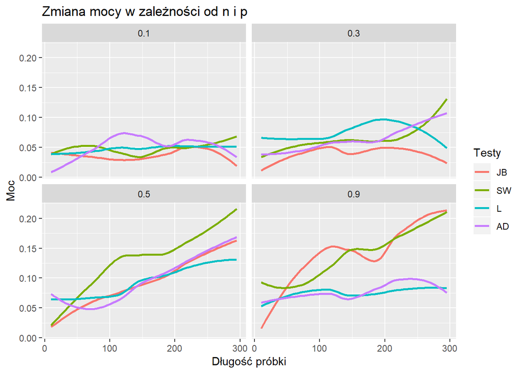

### b) *Zmiana wielkości pierwszego parametru wektora par_1 oraz par_2*

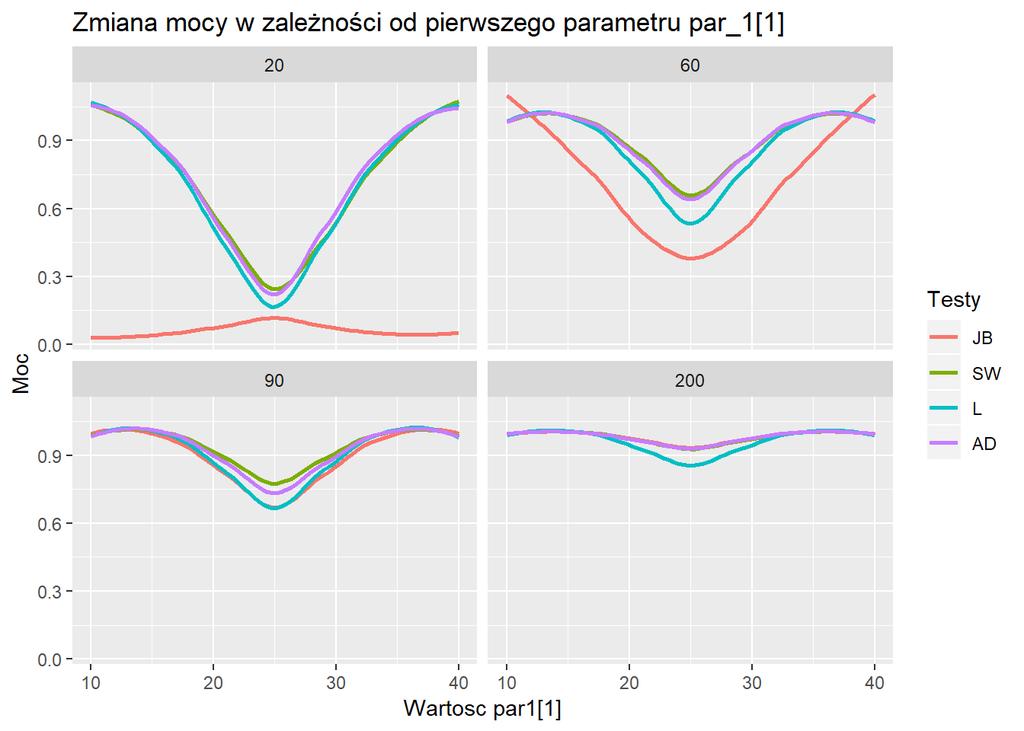

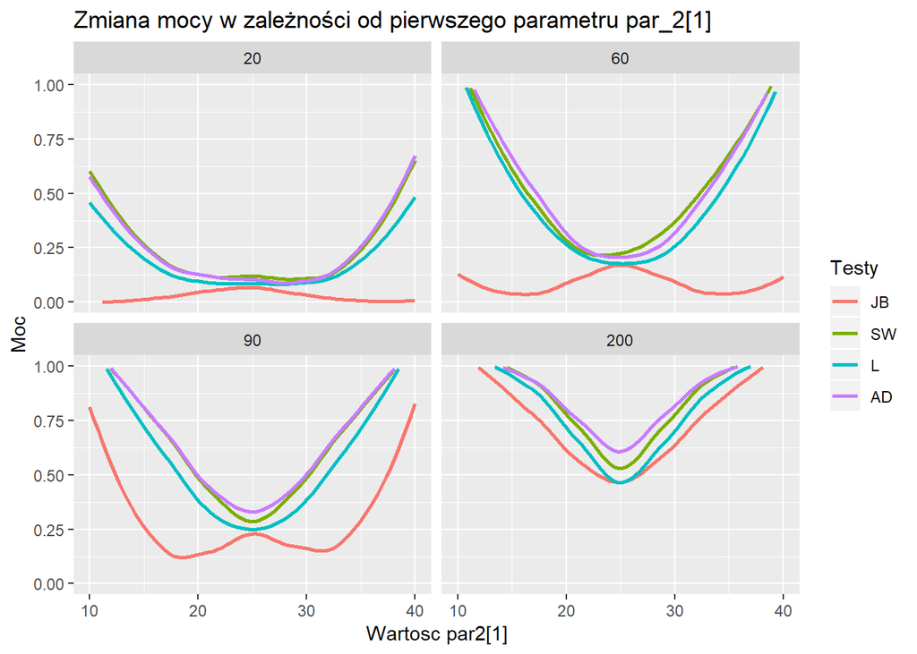

### c) *Zmiana wielkości drugiego parametru wektora par_1 oraz par_2:*

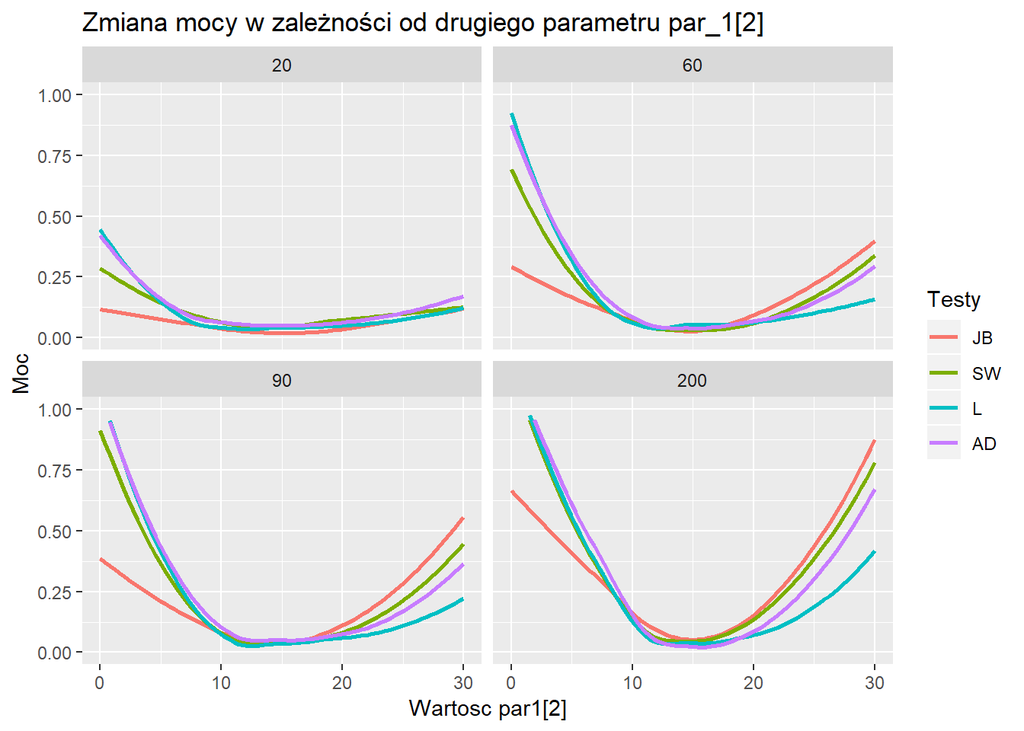

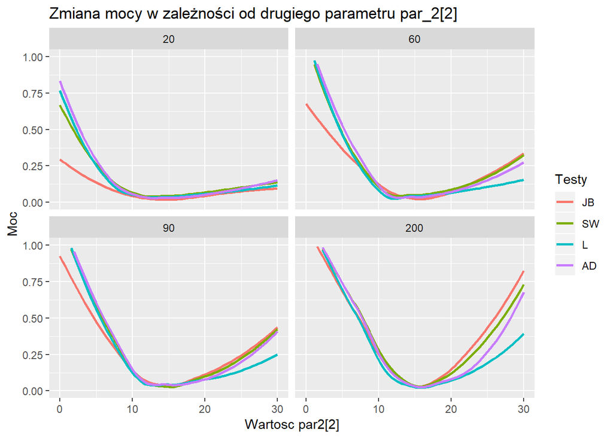